# Section 3

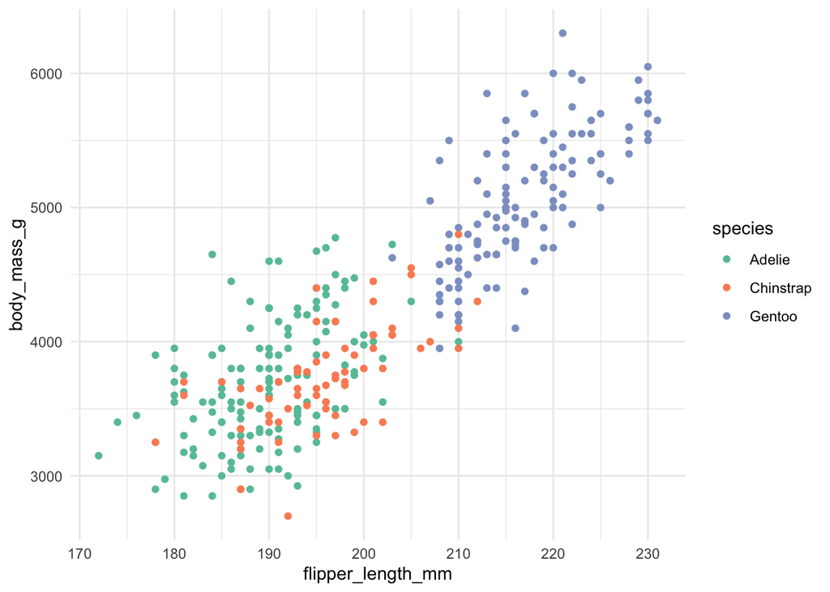

```r
p_penguin <- ggplot(data = penguins_df,
                    aes(x = flipper_length_mm,
                        y = body_mass_g,
                        color = species)) +
  geom_point() +
  scale_color_brewer(palette = 'Set2') +
  theme_minimal()
p_penguin
```

「いいですね！ついでに**軸のタイトルと凡例のタイトル**変えたいです！」

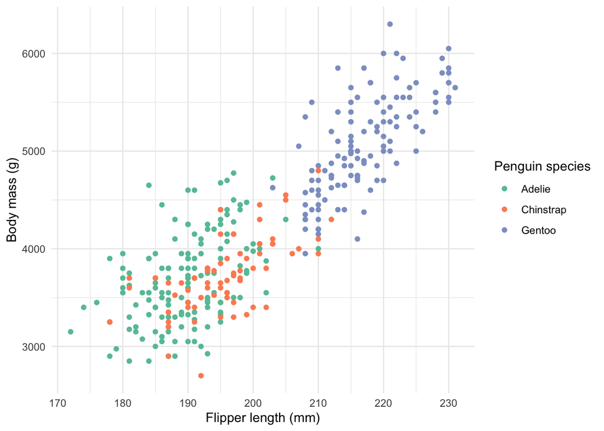

```r
p_penguin <- ggplot(data = penguins_df,
                    aes(x = flipper_length_mm,
                        y = body_mass_g,
                        color = species)) +
  geom_point() +
  scale_color_brewer(palette = 'Set2') +
  labs(x = 'Flipper length (mm)',
       y = 'Body mass (g)',
       color = 'Penguin species') +
  theme_minimal()
p_penguin
```

「もう一個だけいいですか？**図のタイトル**と**キャプション**を追加したくて・・・」

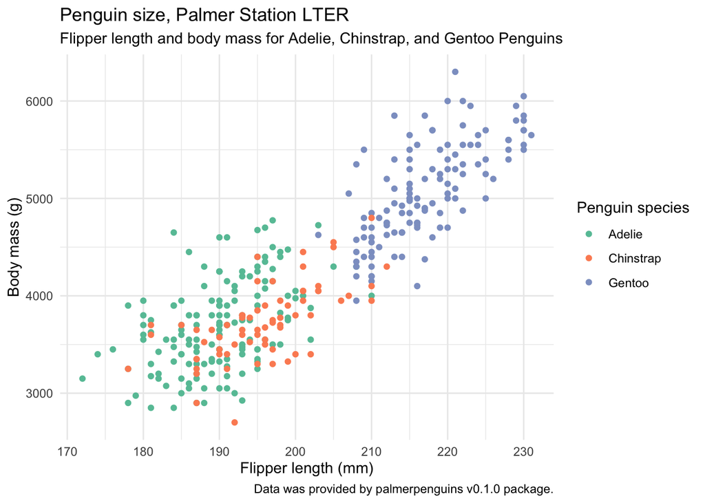

```r
p_penguin <- ggplot(data = penguins_df,
                    aes(x = flipper_length_mm,
                        y = body_mass_g,
                        color = species)) +
  geom_point() +
  scale_color_brewer(palette = 'Set2') +
  labs(x = 'Flipper length (mm)',
       y = 'Body mass (g)',
       color = 'Penguin species',
       title = 'Penguin size, Palmer Station LTER',
       subtitle = 'Flipper length and body mass for Adelie, Chinstrap, and Gentoo Penguins',
       caption = 'Data was provided by palmerpenguins v0.1.0 package.') +
  theme_minimal()
p_penguin
```

## 3.7 保存しよう！

保存するときの形式は2つ。ベクター形式で保存しとくと後で幸せ。

- ベクター形式
  - svg
  - pdf
- ラスター形式
  - jpeg
  - png

```r
ggsave(here::here('figures', 'ss3-flipper-length-vs-body-mass.pdf'),
       p_penguin, height = 12, width = 16, units = 'cm')
```

「あ、ごめんなさい、やっぱりPNG形式がいいです」

```r
ggsave(here::here('figures', 'ss3-flipper-length-vs-body-mass.png'),
       p_penguin, height = 12, width = 16, units = 'cm')
```